# R4DS January Challenge: get involved!

Jesse M

2017-12-29

## Happy New Year!

I love the start of the New Year for so many reasons, but one of my favorites is the never-ending stream of motivational word art that populates a good 98% of every social media feed for 31 whole days, like so:

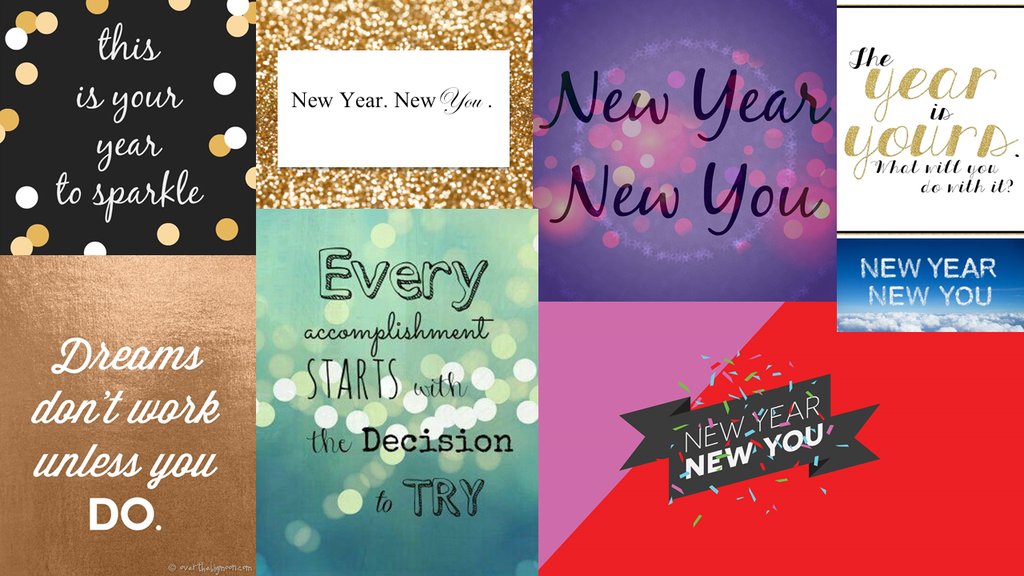

Another reason for loving the start of 2018 is that we’re kicking off the next iteration of the [R for Data Science Online Learning Community](https://www.jessemaegan.com/post/r4ds-the-next-iteration/)! So if you’re joining us for January, consider participating in the January Challenge.

## Mentor challenge

Choose one of the six content channels within Slack, corresponding to the major sections in the [R for Data Science text](http://r4ds.had.co.nz/), and commit to showing up for at least five minutes a day, five days a week, for the month of January.

### “Showing up” can take on a couple of formats:

- Read through people’s questions and discussions for the day
- Answer questions or provide guidance
- Use emoticons to respond to people’s questions or statements

## Learner challenge

Choose one of the six content channels within Slack, corresponding to the major sections in the [R for Data Science text](http://r4ds.had.co.nz/), and commit to working through that section for at least fifteen minutes a day, three days a week, for the month of January.

Then commit to showing up for five minutes a day, five days a week, in the corresponding Slack channel.

### “Showing up” can take on a couple of formats:

- Read through people’s questions and discussions for the day
- Ask your own questions about something you’re working on–nothing is too basic/simple/easy a question!
- Answer questions other people have or provide guidance
- Use emoticons to respond to people’s questions or statements

## And then…

Feel free to share what you’re learning, as it’s a fantastic way to help others learn!

There’s no formal accountability method for this challenge, but feel free to create data visualizations, blog posts, and/or tweets and share them with the community!